# Senegal Key Performance Indicators

Francisco Rios Casas

10/15/2019

### 1. Introduction

This document highlights the data completeness, data sources, and changes over time for select Key Performance Indicators (KPIs) in Senegal. Data for KPIs all came from the latest available Progress Update and Disbursement Request forms (PUDRs) for each grant unless indicated otherwise. Global Fund investment in Senegal include one TB (SEN-Z-MOH), one malaria (SEN-M-PNLP), and two HIV grants (SEN-H-ANCS, SEN-H-CNLS).

### 2. Data Completeness

For each Key Performance Indicator (KPI), the grant Principal Recipient (PR) *usually* must establish an indicator “Baseline Value”. This value–when available–can serve as a benchmark for progress reported in subsequent time periods. **However, in the Senegal grants, the use of the baseline value seems to be inconsistently applied as typically around 50% and 75% of indicators in a given PUDR do not include a Baseline Value.**

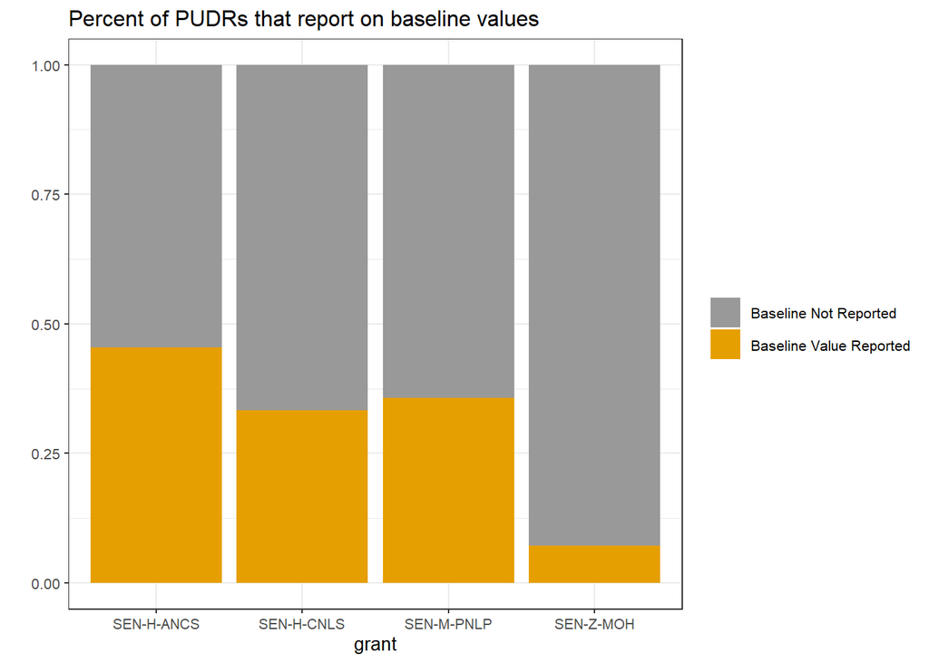

In order to calculate the achievement of a KPI for a given grant, it is necessary to have information on (1) the target that was originally set and (2) the result. Only the malaria (SEN-M-PNLP) and tuberculosis grant (SEN-Z-MOH) in Senegal provide sufficient data to understand how well the grants are meeting the goals that were originally established.

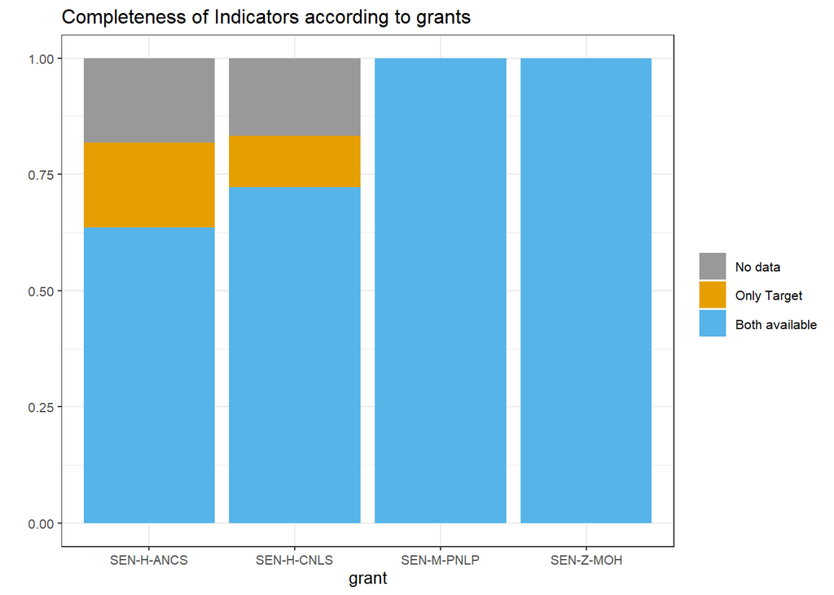

### 3. Data Sources

“Data Sources” are listed in the PUDR to indicate where information reported to the global fund came from. Examples of data sources include reports from the disease-specific National Programs, surveys such as the Demographic Health Survey (DHS), and Health Management Information systems such as DHIS2.

In some cases, the source of information used to establish the target of a goal is different from the source used to provide updates on progress. **In Senegal, the HIV grant to the National HIV Program (CNLS) had indicator sources change the most often: 12 of the 18 indicators in the grant changed sources.**

| Grant | Indicators | Different Sources between Baseline and Result |
| --- | --- | --- |
| SEN-M-PNLP | 14 | 1 |
| SEN-H-ANCS | 11 | 0 |
| SEN-H-CNLS | 18 | 12 |
| SEN-Z-MOH | 14 | 4 |

**In the CNLS grant, the Baseline Values were established using reports from the National HIV Program, while the Result Values were obtained from a combination of DHIS2 data, indicators reported directly from the clinics providing services, and from other reports created by the Ministry of Health.**

### 4. Grant Results based on most recent PUDRs

The “Achievement Ratio” is calculated in the PUDR to understand how close to the original target the KPI result is. A value of 1.0 or greater means that the KPI goal has been met or exceeded.

#### 4.1. TB

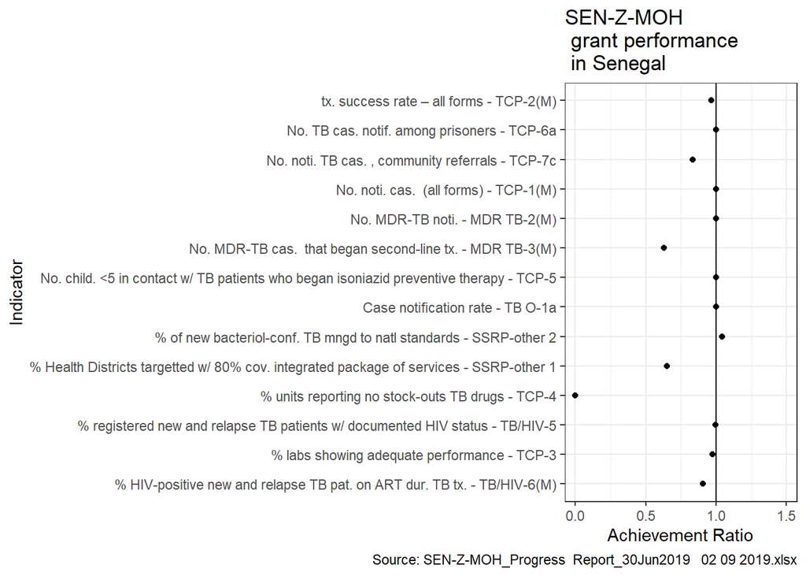

**In the most recent PUDR, the TB grant has reported the lowest performance in the number of reporting units that had no stock-outs of anti-TB drugs. Number of MDR-TB patients that began second line treatment and health district coverage with TB services are the next indicators with the worst performance. Community referrals has also been an area where the indicator results reported have not been meeting the targets set. Section 6 below includes information on progress over time for some of these KPIs.**

#### 4.2. Malaria

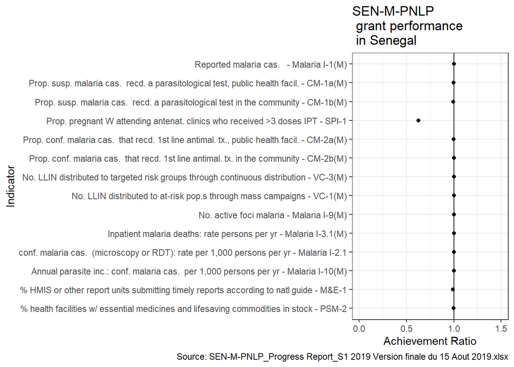

**The Malaria grant has been meeting all of its targets except with regards to the proportion of pregnant women who received at least three doses of IPT.**

#### 4.3. HIV

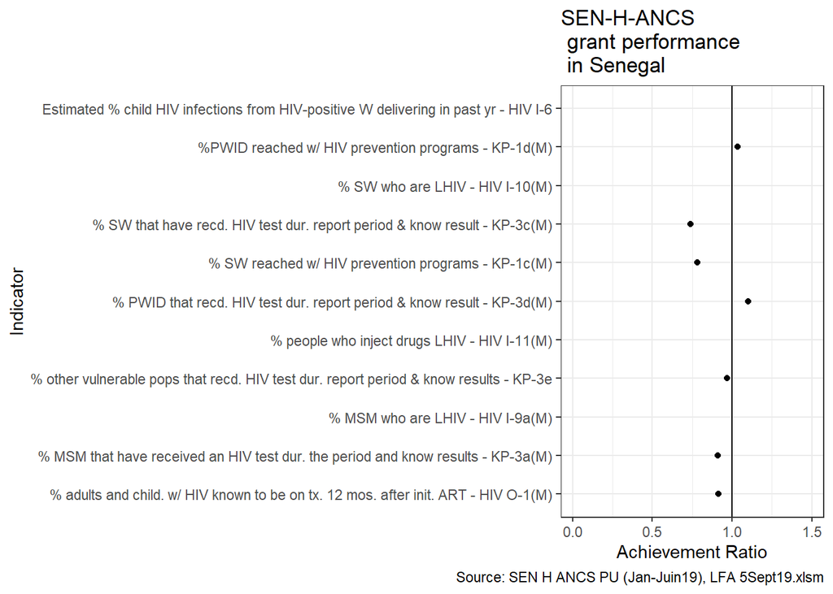

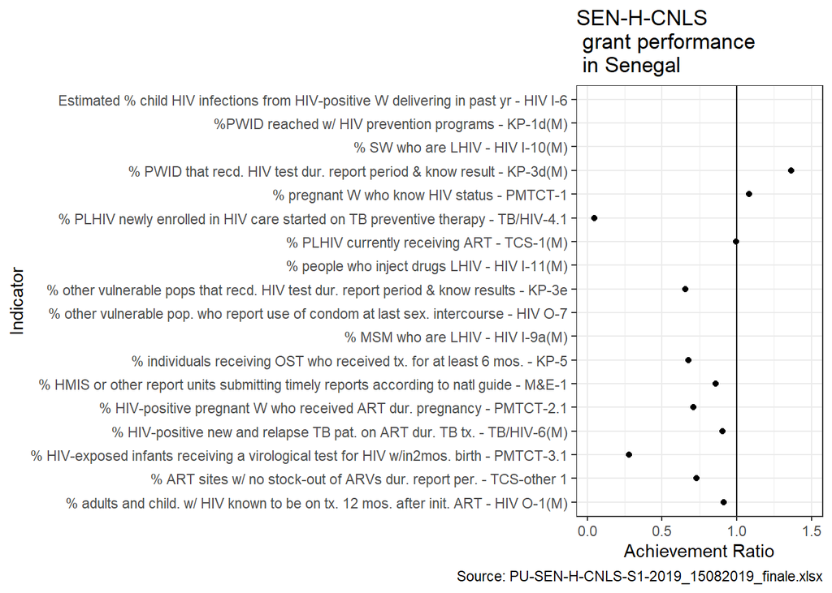

**The HIV ANCS grant has been performing lower than its targets with regards to sex workers. There are also a few KPIs with no updates available.**

**The majority of KPIs between the two HIV grants are different, but in some cases–such as KP-3d(M) testing for HIV among people who inject drugs–both the CNLS and ANCS report different results for the same indicator. The PUDRs for each of the grants also list different targets: while the ANCS grant reports a higher value it also lists a higher target and the CNLS grant lists a lower result but also a much lower target leading to a much higher achievement ratio. Currently, only the ANCS PUDR is LFA-verified however.**

### 5. Agreement between PR, LFA

After each PUDR is submitted by the PR, the LFA will verify the results reported on the KPIs. In many cases they revise the original values provided by the PR.

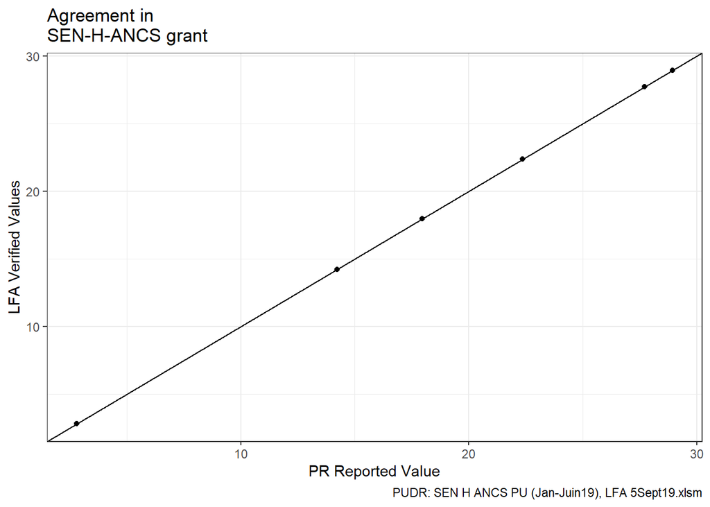

**The most recent LFA-verified PUDR for this analysis is the ANCS grant in Senegal. In this case, there was no corrections made by the LFA to the values reported by the PR.**

### 6. Special Analyses

There are data from three of the most recent PUDRs available for this analysis corresponding to the past 3 semesters that the grants have been implemented. The table below highlights how KPIs for certain indicators of interest in the TB grant have changed over time.

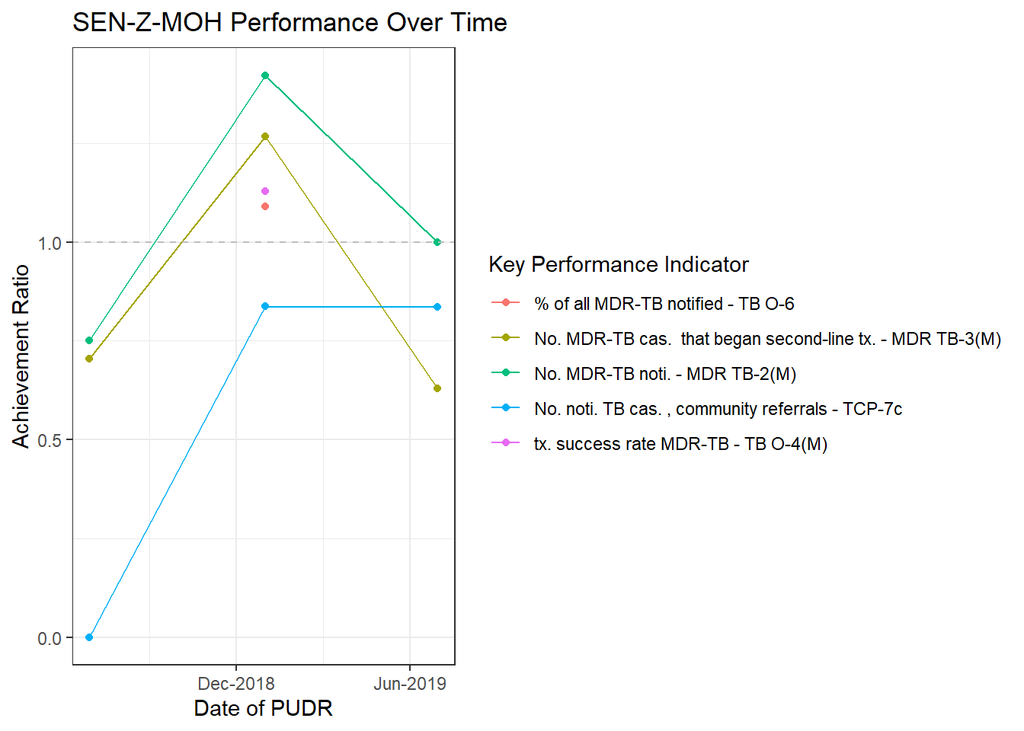

**MDR-TB identification and treatment is an area of large investment by the Global Fund in Senegal and covered in the TB Deep Dive. Progress made in the year 2018 on both of those indicators has somewhat stalled in the first semester of 2019.**

**Although there has been less data available to monitor progress on the treatment and notification of MDR-TB it has been on-track as of the last data available.**

**TB cases identified through community referrals is also an important area of investment in Senegal; this indicator has remained just under-target in the most recent PUDRs.**